# Project-Airline Safety- ISE 201

Pathak, Tanmay Devendra

2023-12-01

**1.INTRODUCTION:**

Research Questions:

1. Should travelers avoid flying airlines that have had crashes in the Past?
2. Have the incidents decreased in the past years, if yes can we expect potential growth in the airline?
3. Are the incidents more prominent in the airlines operating from developing countries?

Related work: https://fivethirtyeight.com/features/should-travelers-avoid-flying-airlines-that-have-had-crashes-in-the-past/

The previous analysis seeked to check if there’s a correlation in crash rates among major commercial airlines over a 30-year span (1985-2014). It involved splitting up this timeframe into two halves (1985-1999 and 2000-2014) to examine crash rates per available seat kilometers (ASKs) i.e. the remaining seat km for the span a data derived from the number of seats which were not filled, regardless of the incident’s cause. The study assumes constant ASKs for airlines since 1985, incorporates only operational airlines by that date, and consolidates data for merged entities and subsidiaries under flagship carriers. Crash parameters include incident rates, fatal accident rates, and rates of fatalities among passengers and crew. The primary objective is to determine whether earlier crash rates (1985-1999) show any predictive correlation with later rates (2000-2014), aiming to discern if an airline’s historical crash record suggests persistent risk or if crashes occur randomly across all airlines at a consistent long-term rate.

**2.Data** **Data Context:**

The context of data explored in this project revolves around the analysis of safety records for major commercial airlines over a 30-year period (1985-2014), sourced from the Aviation Safety Network’s database. The study aims to investigate whether there’s a correlation in crash rates between two distinct halves of this timeframe (1985-1999 and 2000-2014). The method involves assessing crash rates per available seat kilometers (ASKs), assuming a constant ASK value for each airline since 1985, though acknowledging that growth or decline in airlines over time may impact this. The analysis includes all crashes, irrespective of cause, and defines crashes in three ways: incidents regardless of fatalities, fatal accidents, and the rate of fatalities among passengers and crew. Assumptions made include excluding airlines not operational by Jan. 1, 1985, consolidating data for merged entities, and grouping data for regional subsidiaries under their respective flagship carriers. The ultimate goal is to determine if earlier crash rates can predict future crash rates, potentially indicating persistent crash risk linked to specific airlines.

**Data Source:**

Data Source:

1. Silver, N. (2014, July 19). Should Travelers Avoid Flying Airlines That Have Had Crashes in the Past? FiveThirtyEight. https://fivethirtyeight.com/features/should-travelers-avoid-flying-airlines-that-have-had-crashes-in-the-past/
2. Github.com-(https://github.com/fivethirtyeight/data/blob/master/airline-safety/airline-safety.csv)
3. Ranter, H. (2022). Aviation Safety Network > Statistics > By period. Aviation-Safety.net. https://aviation-safety.net/statistics/period/stats.php

**Data Collection:**

The data was collected from Aviation Safety Network’s database and was posted on open source platform GITHUB. The 30-year period is broken down into two halves: first from 1985 to 1999, and then from 2000 to 2014.

**Cases:**

There are two units of observation in this database. One is the accidents in Numbers and other is Available seat kilometers flown every week which is also a numeric variable. The Rows in the data set represent the fatalities happened for every airline carrier from 1985 to 2014.

**Variables:**

The variables I will be studying are Total number of incidents 1985–1999, fatal_accidents_85_99, Total number of fatal accidents 1985–1999, fatalities_85_99, Total number of fatalities 1985–1999 incidents_00_14, Total number of incidents 2000–2014, fatal_accidents_00_14, Total number of fatal accidents 2000–2014, fatalities_00_14, Total number of fatalities 2000–2014.

**Type of study:**

The type of study will purely be observational study, and the aim will be to gather inferences from the data about the safest airline or the airline which has worked on gradually decreasing it’s fatalities over the years.

**Data Cleanup:**

```r
library(tidyverse)
```

```r
library(ggplot2)
library(plyr)
# Import Data

airlinedata <- read.csv("airline-safety.csv")
accidentsdata <- read.csv("accidentsdata.csv")

# Check if data import was as expected
dim(airlinedata)
```

```
## [1] 56  8
```

```r
head(airlinedata)
```

```
##                 airline avail_seat_km_per_week incidents_85_99
## 1            Aer Lingus              320906734               2
## 2             Aeroflot*             1197672318              76
## 3 Aerolineas Argentinas              385803648               6
## 4           Aeromexico*              596871813               3
## 5            Air Canada             1865253802               2
## 6            Air France             3004002661              14
##   fatal_accidents_85_99 fatalities_85_99 incidents_00_14 fatal_accidents_00_14
## 1                     0                0               0                     0
## 2                    14              128               6                     1
## 3                     0                0               1                     0
## 4                     1               64               5                     0
## 5                     0                0               2                     0
## 6                     4               79               6                     2
##   fatalities_00_14
## 1                0
## 2               88
## 3                0
## 4                0
## 5                0
## 6              337
```

```r
# Convert Airline Name into a factor
airlinedata$airline <- as.factor(airlinedata$airline)

# Check data types
data_types <- sapply(airlinedata, class)
print(data_types)
```

```
##                airline avail_seat_km_per_week        incidents_85_99
##               "factor"              "numeric"              "integer"
##  fatal_accidents_85_99       fatalities_85_99        incidents_00_14
##              "integer"              "integer"              "integer"
##  fatal_accidents_00_14       fatalities_00_14
##              "integer"              "integer"
```

```r
# Create 3 new variables by adding the data from years 1985-1999 and 2000-2014.

# Create a new column 'incidents_85_14' by summing 'incidents_85_99' and 'incidents_00_14'
airlinedata$incidents_85_14 <- airlinedata$incidents_85_99 + airlinedata$incidents_00_14

# Create a new column 'fatal_accidents_85_14' by summing 'fatal_accidents_85_99' and 'fatal_accidents_00_14'
airlinedata$fatal_accidents_85_14 <- airlinedata$fatal_accidents_85_99 + airlinedata$fatal_accidents_00_14

# Create a new column 'fatalities_85_14' by summing 'fatalities_85_99' and 'fatalities_00_14'
airlinedata$fatalities_85_14 <- airlinedata$fatalities_85_99 + airlinedata$fatalities_00_14

# Save the updated data set
write_csv(airlinedata, "Updated_airline-safety.csv")

#Immediately create an object for updated data- Later used in Hypothesis Testing
airlinedata_updated <- read.csv("Updated_airline-safety.csv")
```

**Exploratory Data Analysis**

**1.Fatal Accidents comparison between airlines from 1985 to 1999 and 2000-2014**

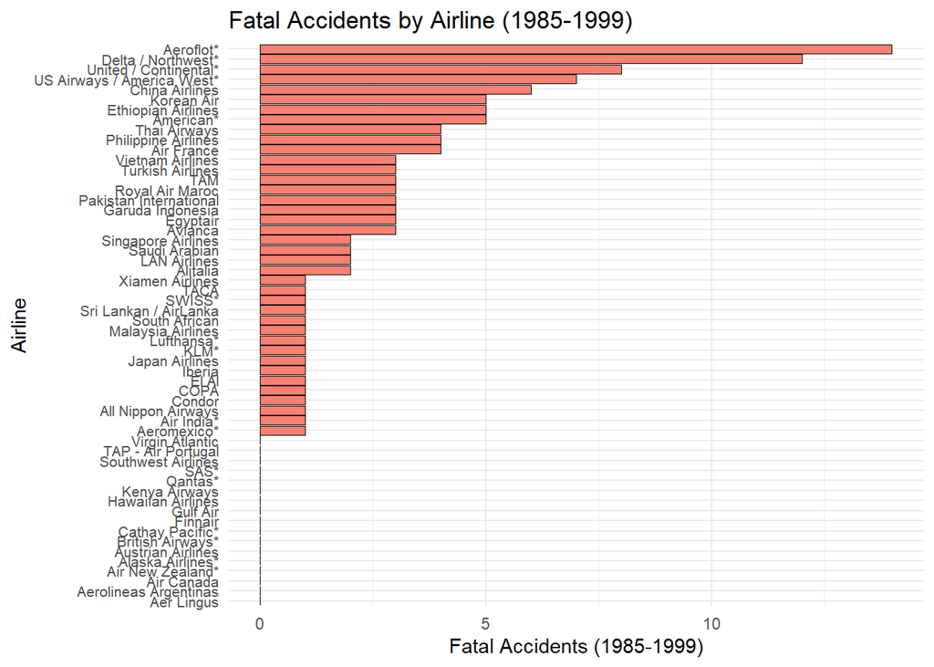

```r
library(ggplot2)
library(gridExtra)
# Define a color palette
my_colors <- c("salmon", "skyblue")

# Bar chart comparing fatal accidents for each airline (1985-1999)
fatal_accidents_85_99_chart <- ggplot(airlinedata, aes(x = reorder(airline, fatal_accidents_85_99), y = fatal_accidents_85_99)) +
  geom_bar(stat = "identity", fill = my_colors[1], color = "black", size = 0.25) +
  coord_flip() +
  labs(title = "Fatal Accidents by Airline (1985-1999)",
       x = "Airline",
       y = "Fatal Accidents (1985-1999)") +
  theme_minimal() +  # Use a minimal theme
  theme(axis.text.y = element_text(size = 8, hjust = 1))  # Adjust text size and alignment
# Bar chart comparing fatal accidents for each airline (2000-2014)
fatal_accidents_00_14_chart <- ggplot(airlinedata, aes(x = reorder(airline, fatal_accidents_00_14), y = fatal_accidents_00_14)) +
  geom_bar(stat = "identity", fill = my_colors[2], color = "black", size = 0.25) +
  coord_flip() +
  labs(title = "Fatal Accidents by Airline (2000-2014)",
       x = "Airline",
       y = "Fatal Accidents (2000-2014)") +
  theme_minimal() +  # Use a minimal theme
  theme(axis.text.y = element_text(size = 8, hjust = 1))  # Adjust text size and alignment

# Display the charts
print(fatal_accidents_85_99_chart)
```

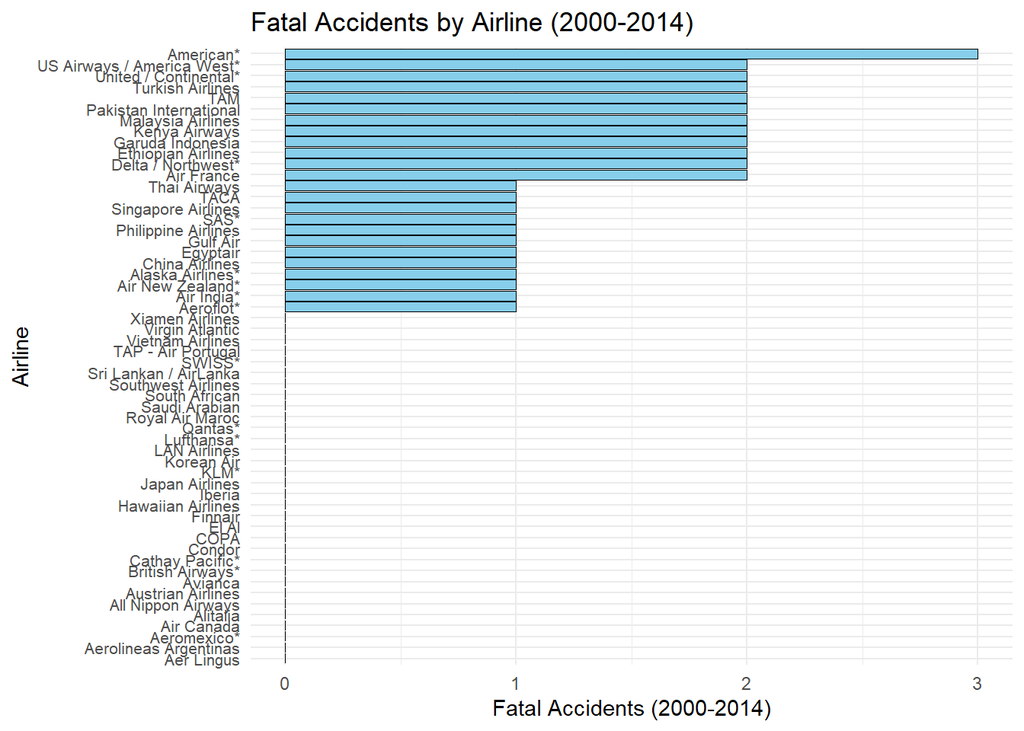

```r
print(fatal_accidents_00_14_chart)
```

**2.Incidents vs. Available Seat Kilometers (ASK) with an overview of fatalities for all airlines**

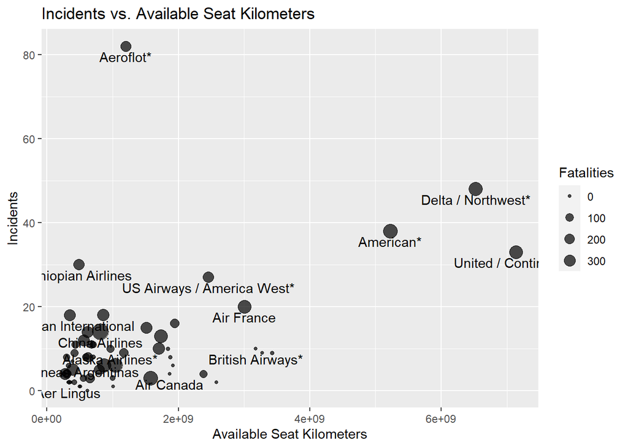

```r
# Scatter plot of incidents vs. available seat kilometers from 1985 to 2014.
scatterplot <- ggplot(airlinedata, aes(x = avail_seat_km_per_week, y = incidents_85_14, label = airline)) +
  geom_point(aes(size = fatalities_85_14), alpha = 0.7) +
  geom_text(check_overlap = TRUE, vjust = 1.5) +
  labs(title = "Incidents vs. Available Seat Kilometers",
       x = "Available Seat Kilometers",
       y = "Incidents") +
  scale_size_continuous(name = "Fatalities", breaks = c(0, 100, 200, 300))

# Display the scatter plot
print(scatterplot)
```

In this plot we can see, Most airlines have a low incidence of accidents in relation to their available seat kilometers, also The size of the points denotes the level of fatalities associated with incidents.Some airlines with higher incidents or fatalities stand out, indicating potential anomalies or specific safety concerns within those carriers. The airlines with most number of Incidents with lowest ASK is Aeroflot, while Delta/Northwest, American and United/Continental have highest number of Available Seat Kilometers their number of Incidents remain fairly average in relation to the ASK. This show us that that incidents by an airline are slighty predictable.

**3.Fatalities distribution for different periods (1985-1999 vs.2000-2014)**

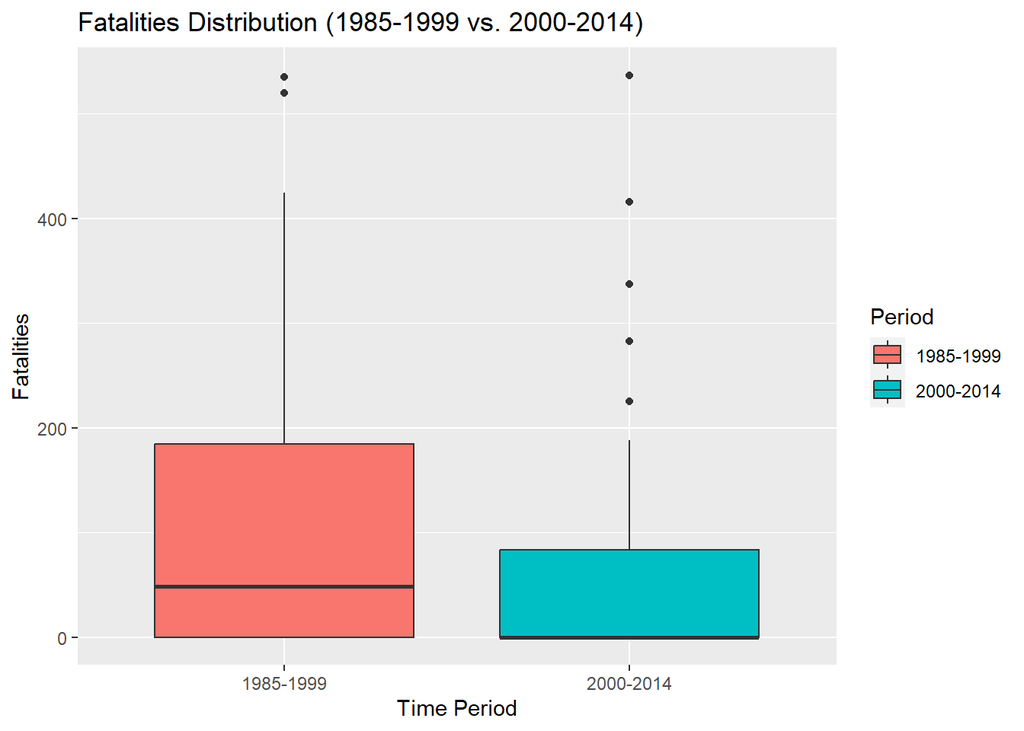

```r
# Combine fatalities data for both time periods
fatalities <- data.frame(
  Period = rep(c("1985-1999", "2000-2014"), each = nrow(airlinedata)),
  Fatalities = c(airlinedata$fatalities_85_99, airlinedata$fatalities_00_14)
)

# Create a boxplot comparing fatalities between time periods
boxplot <- ggplot(fatalities, aes(x = Period, y = Fatalities, fill = Period)) +
  geom_boxplot() +
  labs(title = "Fatalities Distribution (1985-1999 vs. 2000-2014)",
       x = "Time Period",
       y = "Fatalities") +
  scale_fill_discrete(name = "Period")

# Display the boxplot
print(boxplot)
```

**4.Incidents and Fatalities comparison for top airlines**

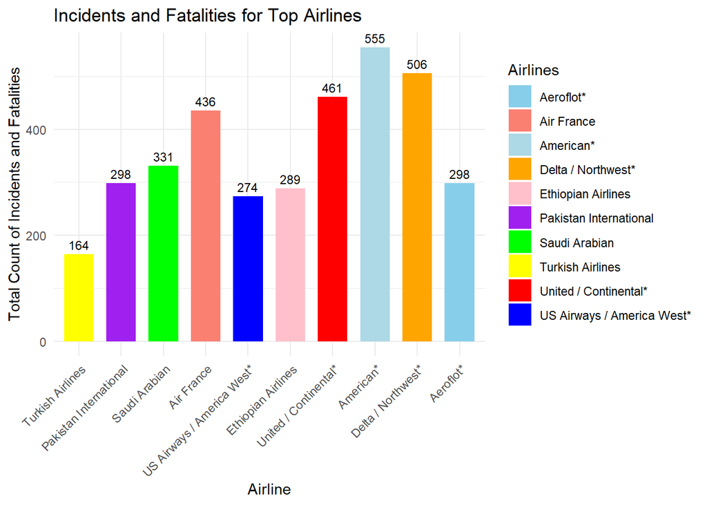

```r
library(ggplot2)
library(dplyr)

# Select top airlines with highest total incidents and fatalities
top_airlines <- airlinedata %>%
  mutate(total_incidents = incidents_85_14,
         total_fatalities = fatalities_85_14) %>%
  arrange(desc(total_incidents)) %>%
  head(10)

# Create a more polished stacked bar chart for top airlines comparing incidents and fatalities
top_airlines_chart <- ggplot(top_airlines, aes(x = reorder(airline, total_incidents), y = total_incidents + total_fatalities, fill = factor(airline))) +
  geom_bar(stat = "identity", width = 0.7) +
  labs(title = "Incidents and Fatalities for Top Airlines",
       x = "Airline",
       y = "Total Count of Incidents and Fatalities") +
  scale_fill_manual(values = c("skyblue", "salmon", "lightblue", "orange", "pink", "purple", "green", "yellow", "red", "blue"),
                    name = "Category") +
  theme_minimal() +
  theme(axis.text.x = element_text(angle = 45, hjust = 1)) +  # Rotate x-axis labels for better readability
  guides(fill = guide_legend(title = "Airlines")) +  # Update legend title
  geom_text(aes(label = total_incidents + total_fatalities), vjust = -0.5, size = 3, color = "black")  # Display values on top of bars

# Display the improved stacked bar chart
print(top_airlines_chart)
```

**5.Trends in incidents over time for individual airlines.**

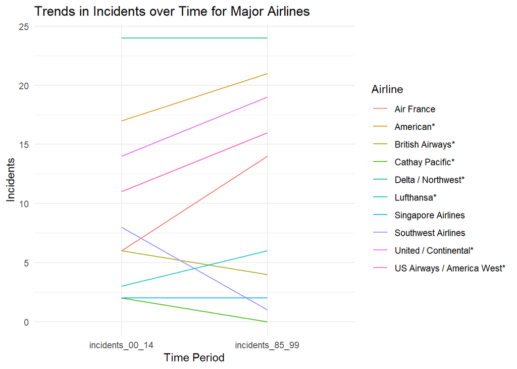

```r
library(ggplot2)

  # Select major airlines with higher available seat kilometers
major_airlines <- airlinedata %>%
  filter(avail_seat_km_per_week > 2000000000) %>%
  select(airline, incidents_85_99, incidents_00_14) %>%
  pivot_longer(cols = c(incidents_85_99, incidents_00_14), names_to = "period", values_to = "incidents")

# Create a line chart showing trends in incidents over time for major airlines
line_chart <- ggplot(major_airlines, aes(x = period, y = incidents, color = airline, group = airline)) +
  geom_line() +
  labs(title = "Trends in Incidents over Time for Major Airlines",
       x = "Time Period",
       y = "Incidents",
       color = "Airline") +
  theme_minimal()

# Display the line chart
print(line_chart)
```

**6.Histograms for incidents, fatal accidents and fatalities over 1985-2014**

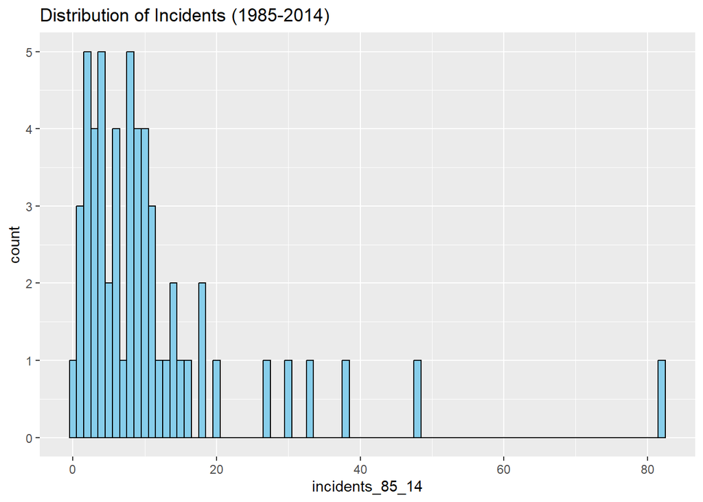

```r
# Histograms for incidents, fatal accidents and fatalities.
ggplot(data = airlinedata, aes(x = incidents_85_14)) +
  geom_histogram(binwidth = 1, fill = "skyblue", color = "black") +
  labs(title = "Distribution of Incidents (1985-2014)")
```

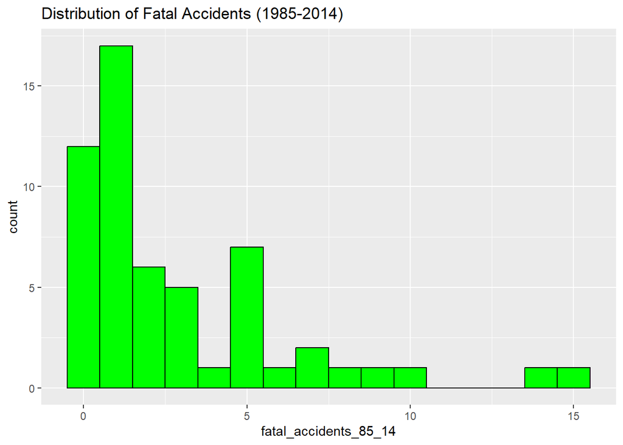

```r
ggplot(data = airlinedata, aes(x = fatal_accidents_85_14)) +
  geom_histogram(binwidth = 1, fill = "green", color = "black") +
  labs(title = "Distribution of Fatal Accidents (1985-2014)")
```

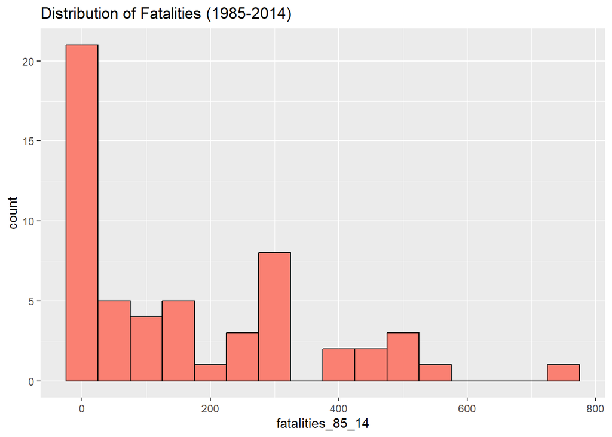

```r
ggplot(data = airlinedata, aes(x = fatalities_85_14)) +
  geom_histogram(binwidth = 50, fill = "salmon", color = "black") +
  labs(title = "Distribution of Fatalities (1985-2014)")
```

As we can see from the 3 Histograms which indicate the count of airlines falling into different ranges of fatalities. The fatalities range for majority of airlines is between 0-200 i.e. the number of fatalities usually lie between 0-200. For fatal accidents it goes between 0-5 wherein for incidents the range where most airlines lie is 0-20.

**For Hypothesis Testing:**

Hypothesis testing is a formal process to validate assumptions made about data collected for experiments. Researchers make assumptions about populations, and hypothesis testing helps determine whether these assumptions hold true.

**Hypothesis testing involves two key hypotheses:**

Null Hypothesis (H0): This hypothesis tests the validity of a claim or assumption made about the population.

Alternative Hypothesis (Ha): This hypothesis is considered valid if the null hypothesis is false.

Hypothesis testing employs a p-value to quantify the strength of evidence provided by data. A small p-value (typically ≤ 0.05) suggests strong evidence against the null hypothesis, leading to its rejection, while a large p-value (> 0.05) implies weak evidence, resulting in the failure to reject the null hypothesis.

**Hypothesis 1**

```r
# Set the null hypothesis (H0) and the alternative hypothesis (Ha)
H0 <- "There is no significant difference in the fatalities from 2000-2014 and 1985-1999"
Ha <- "There is a significant difference in the fatalities from 2000-2014 and 1985-1999"

# Conducting a t-test to compare incidents_00_14 and incidents_85_99
t_test_result <- t.test(airlinedata$fatalities_00_14, airlinedata$fatalities_85_99)

# Displaying the t-test result
print(t_test_result)
```

```
##
##  Welch Two Sample t-test
##
## data:  airlinedata$fatalities_00_14 and airlinedata$fatalities_85_99
## t = -2.3119, df = 102.58, p-value = 0.02278
## alternative hypothesis: true difference in means is not equal to 0
## 95 percent confidence interval:
##  -105.701042   -8.084672
## sample estimates:
## mean of x mean of y
##  55.51786 112.41071
```

```r
# Extract the test statistic and p-value
test_statistic <- t_test_result$statistic
p_value <- t_test_result$p.value

# Set the significance level (alpha)
alpha <- 0.05

# Determine the reference distribution (t-distribution with n-1 degrees of freedom)
# where n is the number of observations in your_data set
degrees_of_freedom <- length(airlinedata$fatalities_00_14+airlinedata$fatalities_85_99) - 2

# Define the rejection criteria
critical_value <- qt(1 - alpha/2, df = degrees_of_freedom)

# Perform the hypothesis test
if (abs(test_statistic) > critical_value || p_value < alpha) {
  conclusion <- "Reject the null hypothesis."
} else {
  conclusion <- "Fail to reject the null hypothesis."
}

# Display the results
cat("Null Hypothesis (HN):", H0, "\n")
```

```
## Null Hypothesis (HN): There is no significant difference in the fatalities from 2000-2014 and 1985-1999
```

```r
cat("Alternative Hypothesis (HA):", Ha, "\n")
```

```
## Alternative Hypothesis (HA): There is a significant difference in the fatalities from 2000-2014 and 1985-1999
```

```r
cat("Test Statistic:", test_statistic, "\n")
```

```
## Test Statistic: -2.311889
```

```r
cat("P-Value:", p_value, "\n")
```

```
## P-Value: 0.02278254
```

```r
cat("Reference Distribution: t-distribution with", degrees_of_freedom, "degrees of freedom\n")
```

```
## Reference Distribution: t-distribution with 54 degrees of freedom
```

```r
if (t_test_result$p.value < 0.05) {
  cat("Conclusion: We reject the null hypothesis. There is a significant difference in the fatalities from 2000-2014 and 1985-1999\n")
} else {
cat("Conclusion: We do not reject the null hypothesis. There is no significant difference in the fatalities from 2000-2014 and 1985-1999\n")
}
```

```
## Conclusion: We reject the null hypothesis. There is a significant difference in the fatalities from 2000-2014 and 1985-1999
```

Conclusion:

The Two Sample t-test conducted on the fatalities reported from 2000-2014 and 1985-1999 within the airline dataset yielded a statistically significant result (t = -2.3119, df = 102.58, p-value = 0.02278). The test concluded a rejection of the null hypothesis, suggesting a substantial discrepancy in the fatalities recorded between these two time frames. Specifically, the mean fatalities reported from 2000-2014 (55.52) significantly differed from those reported from 1985-1999 (112.41). This outcome highlights a notable variation in fatalities between the earlier and later periods studied in the dataset.

**Hypothesis 2**

```r
HN0 <- "There is no significant difference in the incidents from 2000-2014 and 1985-1999"
HA1 <- "There is a significant difference in the incidents from 2000-2014 and 1985-1999"

# Conducting a t-test to compare incidents_00_14 and incidents_85_99
t1_test_result <- t.test(airlinedata$incidents_00_14, airlinedata$incidents_85_99)

# Displaying the t-test result
print(t1_test_result)
```

```
##
##  Welch Two Sample t-test
##
## data:  airlinedata$incidents_00_14 and airlinedata$incidents_85_99
## t = -1.9146, df = 73.136, p-value = 0.05945
## alternative hypothesis: true difference in means is not equal to 0
## 95 percent confidence interval:
##  -6.2320471  0.1249043
## sample estimates:
## mean of x mean of y
##  4.125000  7.178571
```

```r
# Extract the test statistic and p-value
test_statistic <- t1_test_result$statistic
p_value <- t1_test_result$p.value

# Set the significance level (alpha)
alpha <- 0.05

# Determine the reference distribution (t-distribution with n-1 degrees of freedom)
# where n is the number of observations in your_data set
degrees_of_freedom <- length(airlinedata$incidents_00_14+airlinedata$incidents_85_99) - 2

# Define the rejection criteria
critical_value <- qt(1 - alpha/2, df = degrees_of_freedom)

# Perform the hypothesis test
if (abs(test_statistic) > critical_value || p_value < alpha) {
  conclusion <- "Reject the null hypothesis."
} else {
  conclusion <- "Fail to reject the null hypothesis."
}

# Display the results
cat("Null Hypothesis (HN):", HN0, "\n")
```

```
## Null Hypothesis (HN): There is no significant difference in the incidents from 2000-2014 and 1985-1999
```

```r
cat("Alternative Hypothesis (HA):", HA1, "\n")
```

```
## Alternative Hypothesis (HA): There is a significant difference in the incidents from 2000-2014 and 1985-1999
```

```r
cat("Test Statistic:", test_statistic, "\n")
```

```
## Test Statistic: -1.914619
```

```r
cat("P-Value:", p_value, "\n")
```

```
## P-Value: 0.05945278
```

```r
cat("Reference Distribution: t-distribution with", degrees_of_freedom, "degrees of freedom\n")
```

```
## Reference Distribution: t-distribution with 54 degrees of freedom
```

```r
if (t1_test_result$p.value < 0.05) {
  cat("Conclusion: We reject the null hypothesis. There is a significant difference in the incidents from 2000-2014 and 1985-1999\n")
} else {
cat("Conclusion: We do not reject the null hypothesis. There is no significant difference in the incidents from 2000-2014 and 1985-1999\n")
}
```

```
## Conclusion: We do not reject the null hypothesis. There is no significant difference in the incidents from 2000-2014 and 1985-1999
```

**Hypothesis 3**

Two-Sample T-test:

comparing incidents from 1985 to 2014 with the airline accidents data from 1955 to 1984 gathered from the Aviation Safety Network’s database (sample 2). The data gathered from the website has been saved as an sample 2 in another excel file named - accidents data.(data source 3)

```r
# Set the null hypothesis (H0) and the alternative hypothesis (Ha)
HN <- "There is no significant difference in the incidents from 1985-2014 and 1955-1984"
HA <- "There is a significant difference in the incidents from 1985-2014 and 1955-1984"

# Two-sample t-test comparing incidents_85_14 and Accidents_55_84
two_sample_test <- t.test(airlinedata_updated$incidents_85_14,
                          accidentsdata$Airliner_Accidents,
                          alternative = "two.sided",
                          paired = FALSE)
print(two_sample_test)
```

```
##
##  Welch Two Sample t-test
##
## data:  airlinedata_updated$incidents_85_14 and accidentsdata$Airliner_Accidents
## t = -17.865, df = 65.109, p-value < 2.2e-16
## alternative hypothesis: true difference in means is not equal to 0
## 95 percent confidence interval:
##  -56.84546 -45.41407
## sample estimates:
## mean of x mean of y
##  11.30357  62.43333
```

```r
# Extract the test statistic and p-value
test_statistic <- two_sample_test$statistic
p_value <- two_sample_test$p.value

# Set the significance level (alpha)
alpha <- 0.05

# Determine the reference distribution (t-distribution with n-1 degrees of freedom)
# where n is the number of observations in your_data set
degrees_of_freedom <- length(airlinedata_updated$incidents_85_14+accidentsdata$Airliner_Accidents) - 2
# Define the rejection criteria
critical_value <- qt(1 - alpha/2, df = degrees_of_freedom)

# Perform the hypothesis test
if (abs(test_statistic) > critical_value || p_value < alpha) {
  conclusion <- "Reject the null hypothesis."
} else {
  conclusion <- "Fail to reject the null hypothesis."
}

# Display the results
cat("Null Hypothesis (HN):", HN, "\n")
```

```
## Null Hypothesis (HN): There is no significant difference in the incidents from 1985-2014 and 1955-1984
```

```r
cat("Alternative Hypothesis (HA):", HA, "\n")
```

```
## Alternative Hypothesis (HA): There is a significant difference in the incidents from 1985-2014 and 1955-1984
```

```r
cat("Test Statistic:", test_statistic, "\n")
```

```
## Test Statistic: -17.86483
```

```r
cat("P-Value:", p_value, "\n")
```

```
## P-Value: 8.579071e-27
```

```r
cat("Reference Distribution: t-distribution with", degrees_of_freedom, "degrees of freedom\n")
```

```
## Reference Distribution: t-distribution with 54 degrees of freedom
```

```r
if (two_sample_test$p.value < 0.05) {
  cat("Conclusion: We reject the null hypothesis. There is a significant difference in the incidents from 1985-2014 and 1955-1984.\n")
} else {
cat("Conclusion: We do not reject the null hypothesis. There is no significant difference in the incidents from 1985-2014 and 1955-1984.\n")
}
```

```
## Conclusion: We reject the null hypothesis. There is a significant difference in the incidents from 1985-2014 and 1955-1984.
```

Conclusion:

The statistical analysis, employing a two-sample t-test, compared the incidents reported from 1985 to 2014 with the historical airline accidents data spanning 1955 to 1984. The test decisively rejects the null hypothesis, indicating a substantial disparity in incident frequencies between these time frames (p-value < 0.05). Notably, the mean incidents from 1985 to 2014 (11.30) significantly contrast with the mean accidents reported from 1955 to 1984 (62.43). This outcome strongly suggests a marked difference in incident rates between the two periods, signifying a significant shift in aviation incident reporting and safety measures over these distinct time spans.

**Linear Regression**

```r
# Performing linear regression on airline data - predicting incidents from 2000-2014 using data from 1985-1999.
lm_result <- lm(incidents_00_14 ~ incidents_85_99 + fatal_accidents_85_99 + fatalities_85_99 + avail_seat_km_per_week, data = airlinedata)


# Summary of the linear regression model
summary(lm_result)
```

```
##
## Call:
## lm(formula = incidents_00_14 ~ incidents_85_99 + fatal_accidents_85_99 +
##     fatalities_85_99 + avail_seat_km_per_week, data = airlinedata)
##
## Residuals:
##     Min      1Q  Median      3Q     Max
## -4.9904 -2.1680 -0.1232  1.8497  8.1809
##
## Coefficients:
##                          Estimate Std. Error t value Pr(>|t|)
## (Intercept)             6.929e-01  6.273e-01   1.105   0.2745
## incidents_85_99        -4.194e-02  8.335e-02  -0.503   0.6170
## fatal_accidents_85_99   6.637e-01  3.959e-01   1.676   0.0998 .
## fatalities_85_99       -1.347e-03  3.708e-03  -0.363   0.7179
## avail_seat_km_per_week  1.761e-09  3.300e-10   5.337 2.19e-06 ***
## ---
## Signif. codes:  0 '***' 0.001 '**' 0.01 '*' 0.05 '.' 0.1 ' ' 1
##
## Residual standard error: 2.99 on 51 degrees of freedom
## Multiple R-squared:  0.5986, Adjusted R-squared:  0.5672
## F-statistic: 19.02 on 4 and 51 DF,  p-value: 1.263e-09
```

Conclusion of Linear Regression: The linear regression analysis aimed to predict incidents from 2000 to 2014 using data from 1985 to 1999, fatal accidents, fatalities, and available seat kilometers per week. The model’s coefficients revealed that available seat kilometers per week showed a statistically significant relationship (p-value: 2.19e-06) with incidents_00_14, while incidents_85_99, fatal_accidents_85_99, and fatalities_85_99 did not individually exhibit significant associations. The overall model was significant (F-statistic: 19.02, p-value: 1.263e-09), explaining approximately 56.72% of the variability in incidents_00_14, yet only the availability of seat kilometers per week appeared to notably influence incidents_00_14 based on the coefficients’ significance levels.

**Project Conclusion:**

The linear regression analysis aimed to predict incidents from 2000 to 2014 using various parameters. It revealed that available seat kilometers per week significantly correlated with incidents_00_14, while other variables didn’t show significant individual associations. This highlights the importance of seat availability in predicting incidents during the specified period.

However, several limitations and future directions should be acknowledged. The data focused on crash rates and incidents but might benefit from a broader inclusion of safety metrics or more specific causes of incidents. Additionally, future research could dive deeper into regional influences on safety, considering various factors unique to developing countries. Exploring the impact of specific safety measures implemented by airlines could provide richer insights into reducing incidents. Lastly, incorporating more recent data beyond 2014 could offer a more up-to-date understanding of current safety trends. This data can be obtained from the Aviation Safety Network’s database.

The project not only shed light on airline safety but also underscored the dynamic nature of aviation safety standards and the importance of continuous efforts toward enhancing safety measures. Learning from this analysis involves recognizing that while improvements are evident, there’s a perpetual need for vigilance and refinement in ensuring aviation safety for passengers and crew alike.

**References** (Cited in APA7 format)

1. Silver, N. (2014, July 19). Should Travelers Avoid Flying Airlines That Have Had Crashes in the Past? FiveThirtyEight. https://fivethirtyeight.com/features/should-travelers-avoid-flying-airlines-that-have-had-crashes-in-the-past/
2. data/airline-safety at master · fivethirtyeight/data. (n.d.). GitHub. https://github.com/fivethirtyeight/data/tree/master/airline-safety
3. Ranter, H. (2022). Aviation Safety Network > Statistics > By period. Aviation-Safety.net. https://aviation-safety.net/statistics/period/stats.php